# Machine Learning Engineer Nanodegree - Capstone Project

Topic: Customer CHurn Prediction

- author: Jin Kwon

REF:

- lightgbm https://medium.com/swlh/dealing-with-categorical-variables-in-machine-learning-4401b949b093

```python
import pandas as pd
import numpy as np


# data vis.
import seaborn as sns
import matplotlib.pyplot as plt
import plotly.graph_objects as go
from plotly.subplots import make_subplots


# data engineering
from sklearn.preprocessing import OneHotEncoder
from sklearn.model_selection import train_test_split
from sklearn.preprocessing import StandardScaler
from imblearn.over_sampling import SMOTE
from imblearn.over_sampling import SMOTENC
from imblearn.under_sampling import RandomUnderSampler


# metrics
from sklearn.metrics import roc_auc_score
from sklearn.metrics import roc_curve
from sklearn.metrics import roc_auc_score
from sklearn.metrics import precision_score
from sklearn.metrics import recall_score

# modeling
from sklearn.linear_model import LogisticRegression
from sklearn.ensemble import RandomForestClassifier
from sklearn.ensemble import GradientBoostingClassifier
from sklearn.svm import SVC
from catboost import CatBoostClassifier

from sklearn.model_selection import RepeatedStratifiedKFold
from sklearn.model_selection import GridSearchCV


# others
from scipy.stats.stats import pearsonr
```

## 0. Load Data

```python
data_df = pd.read_csv('../data/data.csv')
data_df.head()
```

|  | customerID | gender | SeniorCitizen | Partner | Dependents | tenure | PhoneService | MultipleLines | InternetService | OnlineSecurity | ... | DeviceProtection | TechSupport | StreamingTV | StreamingMovies | Contract | PaperlessBilling | PaymentMethod | MonthlyCharges | TotalCharges | Churn |
| --- | --- | --- | --- | --- | --- | --- | --- | --- | --- | --- | --- | --- | --- | --- | --- | --- | --- | --- | --- | --- | --- |
| 0 | 7590-VHVEG | Female | 0 | Yes | No | 1 | No | No phone service | DSL | No | ... | No | No | No | No | Month-to-month | Yes | Electronic check | 29.85 | 29.85 | No |
| 1 | 5575-GNVDE | Male | 0 | No | No | 34 | Yes | No | DSL | Yes | ... | Yes | No | No | No | One year | No | Mailed check | 56.95 | 1889.5 | No |
| 2 | 3668-QPYBK | Male | 0 | No | No | 2 | Yes | No | DSL | Yes | ... | No | No | No | No | Month-to-month | Yes | Mailed check | 53.85 | 108.15 | Yes |
| 3 | 7795-CFOCW | Male | 0 | No | No | 45 | No | No phone service | DSL | Yes | ... | Yes | Yes | No | No | One year | No | Bank transfer (automatic) | 42.30 | 1840.75 | No |
| 4 | 9237-HQITU | Female | 0 | No | No | 2 | Yes | No | Fiber optic | No | ... | No | No | No | No | Month-to-month | Yes | Electronic check | 70.70 | 151.65 | Yes |

5 rows × 21 columns

```python
# 1. `TotalCharges` is imported as a String
data_df['TotalCharges'] = pd.to_numeric(data_df['TotalCharges'], errors='coerce')


# 2. `SeniorCitizen` is using the Numeric 0 and 1 as a binary label, which is
#     not consistent with other binary categorical labels using `Yes` and `No`
#     Change this.
def to_bool(val):
    if val == True:
        return('Yes')
    else:
        return('No')

data_df['SeniorCitizen'] = data_df['SeniorCitizen'].apply(to_bool)# 3.
```

## 1. Data Exploration & Preprocessing

### 1.1. Check `NA`

```python
print(" \nCount total NaN at each column in a DataFrame : \n\n", data_df.isnull().sum())
```

```
Count total NaN at each column in a DataFrame :

 customerID           0
gender               0
SeniorCitizen        0
Partner              0
Dependents           0
tenure               0
PhoneService         0
MultipleLines        0
InternetService      0
OnlineSecurity       0
OnlineBackup         0
DeviceProtection     0
TechSupport          0
StreamingTV          0
StreamingMovies      0
Contract             0
PaperlessBilling     0
PaymentMethod        0
MonthlyCharges       0
TotalCharges        11
Churn                0
dtype: int64
```

### 1.2. Univariate Exploration

#### 1.2.1. Numerical Variables

```python
numerical_col = data_df._get_numeric_data().columns
categorical_col = set(data_df.columns) - set(numerical_col)
```

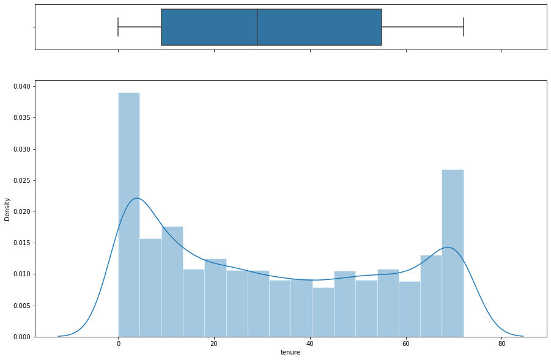

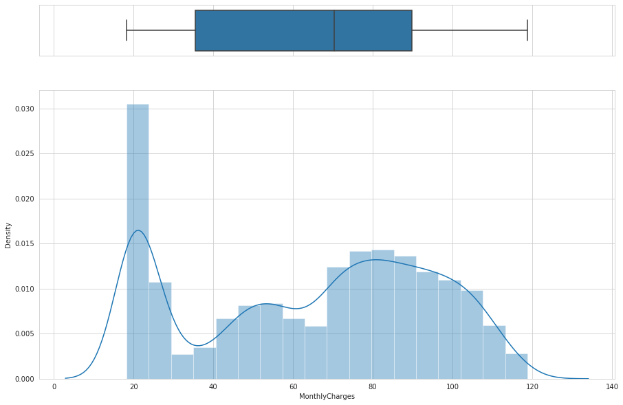

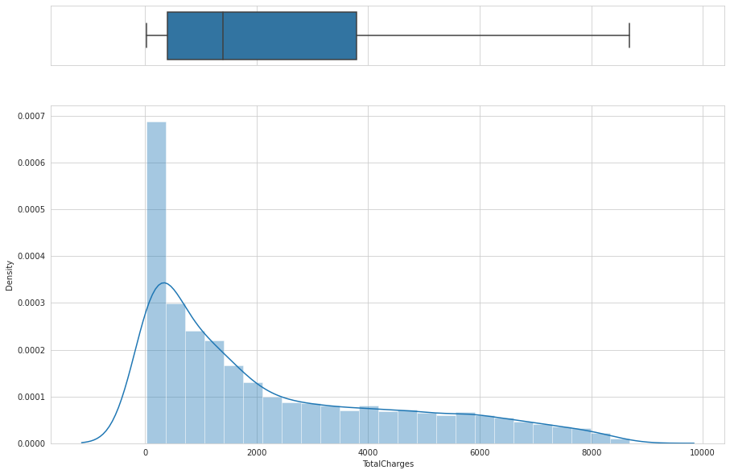

```python
for col in numerical_col:
    # Cut the window in 2 parts
    f, (ax_box, ax_hist) = plt.subplots(2,figsize = (15, 10), sharex=True, gridspec_kw={"height_ratios": (.15, .85)})

    # Add a graph in each part
    sns.set_style("whitegrid")
    sns.boxplot(data_df[col], ax=ax_box)
    sns.distplot(data_df[col], ax=ax_hist)

    # Remove x axis name for the boxplot
    ax_box.set(xlabel='')
```

**OBSERVATIONS:**.

- There seems to be no concerning outliers.
- `MonthlyCharges` column has a high concentration around 20, and the rest the values are somewhat a normal distribution with skew to the left.
- `TotalCharges` column seem to follow an exponential distribution.

#### 1.2.2. Categorical Variables

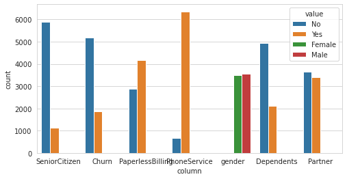

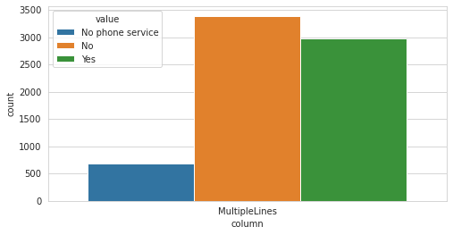

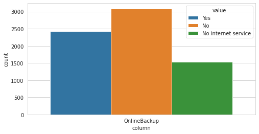

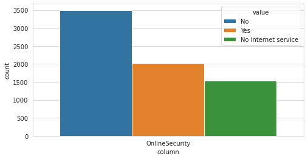

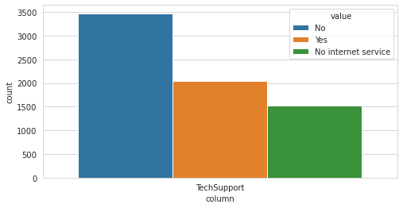

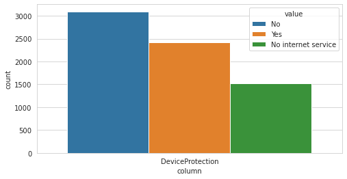

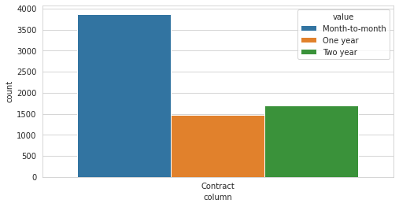

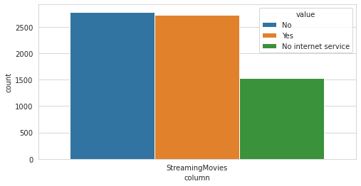

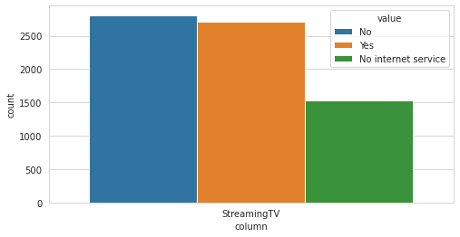

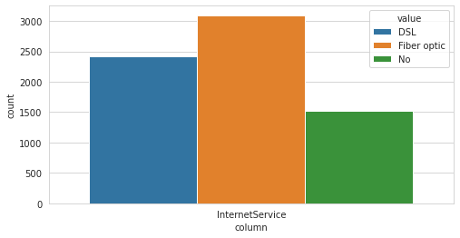

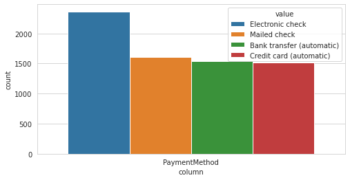

```python
# only yes or no
cate_plot_df = data_df[['customerID'] + list(categorical_col)].set_index('customerID').stack().reset_index()
cate_plot_df.columns = ['customerID', 'column', 'value']

for col_list in [['Churn',
  'SeniorCitizen',
  'PhoneService',
  'Partner',
  'PaperlessBilling',
  'Dependents',
  'gender'],
 ['MultipleLines'],
  ['OnlineBackup'],
  ['OnlineSecurity'],
  ['TechSupport'],
  ['DeviceProtection'],
  ['Contract'],
  ['StreamingMovies'],
  ['StreamingTV'],
  ['InternetService'],
 ['PaymentMethod']]:
    f, axs = plt.subplots(1,1,figsize=(8,4))
    ax = sns.countplot(x="column", hue="value", data=cate_plot_df[cate_plot_df['column'].isin(col_list)])
```

**OBSERVATIONS:**

| `PhoneService` | `MultipleLines` |
| --- | --- |
| No | No phone service |
| Yes | Yes |
| Yes | No |

| `InteretService` | `OnlineSecurity`, `OnlineBackup`, `DeviceProtection`, `TechSupport`, `StreamingTV`, `StreamingMovie` |
| --- | --- |
| No | No internet service |
| Yes | Yes |
| Yes | No |

The column values on the right are dependent on the column values on the left, thus 7 columns alone can explain the 2 columns on the left.

### 1.3. Bivariate Exploration

#### 1.3.1. Numerically Correlated Columns using Pearson Correlation

`TotalCharges` correlated with `MonthlyCharges`*`Tenure`?

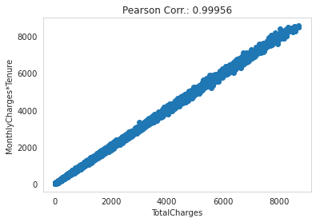

```python
data_df2 = data_df.dropna()

tot_charge = data_df2['TotalCharges'].tolist()
monthly_tenure_mult = [a*b for a,b in zip(data_df2['MonthlyCharges'], data_df2['tenure'])]

corr = np.round(pearsonr(tot_charge, monthly_tenure_mult)[0], 5)
plt.scatter(tot_charge, monthly_tenure_mult)
plt.title('Pearson Corr.: ' + str(corr))
plt.xlabel('TotalCharges')
plt.ylabel('MonthlyCharges*Tenure')
plt.grid()
```

**OBSERVATION:**

- The scatter plot indicates nearly perfectly linear correlation
- `MonthlyCharges`*`tenure` is nearly identical to `TotalCharges`. Thus, we can remove `TotalCharges` column because from having two separate columns `MonthlyCharges` and `tenure` we can get more information.

```python
data_df.drop(columns = ['TotalCharges'], inplace = True)
```

```python
# any other correlation?
data_df.corr()
```

|  | tenure | MonthlyCharges |
| --- | --- | --- |
| tenure | 1.0000 | 0.2479 |
| MonthlyCharges | 0.2479 | 1.0000 |

**OBSERVATION:** The rest of the numerical columns seem uncorrealated.

#### 1.3.2. Categorically correlated features using Contingency Table

```python
# MultipleLines vs. PhoneService
pd.crosstab(data_df['MultipleLines'], data_df['PhoneService'])
```

| PhoneService MultipleLines | No | Yes |
| --- | --- | --- |
| No | 0 | 3390 |
| No phone service | 682 | 0 |
| Yes | 0 | 2971 |

**OBSERVATION:**

- `MultipleLine` column is enough to describe `PhoneService` column and provides additional information. We can drop `PhoneService` column.

```python
data_df.drop(columns = ['PhoneService'], inplace = True)
```

```python
# InternetService vs. MultipleLines
display(pd.crosstab(data_df['InternetService'], data_df['MultipleLines']))

# OnlineSecurity vs. OnlineBackup
display(pd.crosstab(data_df['OnlineSecurity'], data_df['OnlineBackup']))

# Partner vs. Dependents
display(pd.crosstab(data_df['Partner'], data_df['Dependents']))
```

| MultipleLines InternetService | No | No phone service | Yes |
| --- | --- | --- | --- |
| DSL | 1048 | 682 | 691 |
| Fiber optic | 1158 | 0 | 1938 |
| No | 1184 | 0 | 342 |

| OnlineBackup OnlineSecurity | No | No internet service | Yes |
| --- | --- | --- | --- |
| No | 2195 | 0 | 1303 |
| No internet service | 0 | 1526 | 0 |
| Yes | 893 | 0 | 1126 |

| Dependents Partner | No | Yes |
| --- | --- | --- |
| No | 3280 | 361 |
| Yes | 1653 | 1749 |

**OBSERVATION:**

- Other columns don't have significant correlation. So we will keep the rest of the categorical columns.

## 2. Train/Test Data Split

- To use consistent train and test data sets, split expsting data to train and test.
- Stratify by columns that are highly skewed to preserve the original distribution in the data.

```python
def select_data(data_type):
    if data_type == 'SMOTE-ENC':
        return (X_train_smotenc, y_train_smotenc)
    elif data_type == 'undersample1':
        return (X_train_under1, y_train_under1)
    elif data_type == 'undersample2':
        return (X_train_under2, y_train_under2)
    elif data_type == 'SMOTE':
        return (X_train_smote, y_train_smote)
    else:
        return (X_train_onehot, y_train_onehot)
```

```python
# train test split
train_df, test_df = train_test_split(data_df, test_size=0.2, stratify = data_df[['Churn']], random_state = 42)

features = train_df.columns.tolist()
features.remove('customerID')
features.remove('Churn')

X_train = train_df[features]
X_test  = test_df[features]

X_train_org = X_train
X_test_org  = X_test

y_train = train_df['Churn'].tolist()
y_test  = test_df['Churn'].tolist()

y_train_org = y_train
y_test_org  = y_test

# one-hot encode categorical features
# NOTE: ensure that we fit the one-hot-encoder only using the training data!
numerical_col  = X_train._get_numeric_data().columns.tolist()
categorical_col = set(X_train.columns) - set(numerical_col)
categorical_col = list(categorical_col)


# one hot encode Categofical columns
X_train_onehot = pd.DataFrame()
X_test_onehot = pd.DataFrame()

for col in categorical_col:
    enc = OneHotEncoder(handle_unknown='error', drop = 'first')
    train_temp = pd.DataFrame(enc.fit_transform(X_train[[col]]).toarray())
    train_temp.columns = enc.get_feature_names([col])

    test_temp = pd.DataFrame(enc.transform(X_test[[col]]).toarray())
    test_temp.columns = enc.get_feature_names([col])

    X_train_onehot = pd.concat([X_train_onehot, train_temp], axis=1)
    X_test_onehot = pd.concat([X_test_onehot, test_temp], axis=1)


# append Numerical columns
X_train_onehot.reset_index(drop=True, inplace=True)
X_test_onehot.reset_index(drop=True, inplace=True)
train_temp = X_train[numerical_col].reset_index(drop=True)
test_temp = X_test[numerical_col].reset_index(drop=True)

X_train_onehot = pd.concat([X_train_onehot, train_temp], axis=1)
X_test_onehot = pd.concat([X_test_onehot, test_temp], axis=1)


y_train_onehot = [1 if el == 'Yes' else 0 for el in y_train]
y_test_onehot  = [1 if el == 'Yes' else 0 for el in y_test]


## Min-Max Scale
scaler = StandardScaler()
X_train_onehot[numerical_col] = scaler.fit_transform(X_train_onehot[numerical_col])
X_test_onehot[numerical_col] = scaler.transform(X_test_onehot[numerical_col])
```

## Data OverSample UnderSample

We will explore four differnt upsample and downsample methods.

```python
# undersample 1 - same size as minority class
# downsample the majority to have the same size as the minority class
undersample_1 = RandomUnderSampler(sampling_strategy='majority')
X_train_under1, y_train_under1 = undersample_1.fit_resample(X_train_onehot, y_train_onehot)

# undersample 2 - 1.5 the size of minority class
# downsample the majority to have the 1.5 the size of the minority class
undersample_2 = RandomUnderSampler(sampling_strategy=0.667)
X_train_under2, y_train_under2 = undersample_2.fit_resample(X_train_onehot, y_train_onehot)

# oversample w/ SMOTE
# use default SMOTE method to oversample the minority class and have
# the same sample size as the majority class
oversample = SMOTE()
X_train_smote, y_train_smote = oversample.fit_resample(X_train_onehot, y_train_onehot)

# oversample w/ SMOTE NC
# same as above but treating one-hot encoded categorical variables as
# categorical features
smotenc = SMOTENC([0, 1, 2, 3, 5, 6, 7, 8, 9, 10, 11, 12, 13, 14, 15], random_state = 42)
X_train_smotenc, y_train_smotenc = smotenc.fit_resample(X_train_onehot, y_train_onehot)
```

ref: https://machinelearningmastery.com/hyperparameters-for-classification-machine-learning-algorithms/

GridSearchCV using `scoring` ROC_AUC

## Base Model 0 - Logistic Regression

As a base model, we will use logistic regression. But, we will try to have this optimized as much as possible using the sklearn's GridSearchCV().

```python
%%time

model = LogisticRegression()

# hyperparameter search space
solvers = ['newton-cg', 'lbfgs', 'liblinear']
penalty = ['l2']
c_values = [100, 10, 1.0, 0.1, 0.01]

# initialize logistic regression hyperparameter
lr_hyperparam_df = pd.DataFrame(columns = ['sampling_method', 'solver', 'penalty', 'C', 'roc_auc'])

# define grid search
grid = dict(solver = solvers,
            penalty = penalty,
            C = c_values)

# define cross-validation
cv = RepeatedStratifiedKFold(n_splits=12, n_repeats=3, random_state=42)

# initialize grid search instance
grid_search = GridSearchCV(estimator=model,
                           param_grid=grid,
                           n_jobs=-1,
                           scoring='roc_auc',
                           error_score=0,
                           cv = cv)


# conduct grid search
print('Grid Search... original training data')
grid_result_org = grid_search.fit(X_train_onehot, y_train_onehot)
res_dict = grid_result_org.best_params_
res_dict['sampling_method'] = 'none'
res_dict['roc_auc'] = round(grid_result_org.best_score_, 3)
lr_hyperparam_df = lr_hyperparam_df.append(res_dict, True)

print('Grid Search... undersampling method 1')
grid_result_under1 = grid_search.fit(X_train_under1, y_train_under1)
res_dict = grid_result_under1.best_params_
res_dict['sampling_method'] = 'undersample1'
res_dict['roc_auc'] = round(grid_result_under1.best_score_, 3)
lr_hyperparam_df = lr_hyperparam_df.append(res_dict, True)

print('Grid Search... undersampling method 2')
grid_result_under2 = grid_search.fit(X_train_under2, y_train_under2)
res_dict = grid_result_under2.best_params_
res_dict['sampling_method'] = 'undersample2'
res_dict['roc_auc'] = round(grid_result_under2.best_score_, 3)
lr_hyperparam_df = lr_hyperparam_df.append(res_dict, True)

print('Grid Search... oversampling w/ SMOTE')
grid_result_over1 = grid_search.fit(X_train_smote, y_train_smote)
res_dict = grid_result_over1.best_params_
res_dict['sampling_method'] = 'SMOTE'
res_dict['roc_auc'] = round(grid_result_over1.best_score_, 3)
lr_hyperparam_df = lr_hyperparam_df.append(res_dict, True)

print('Grid Search... oversampling w/ SMOTE-ENC')
grid_result_over2 = grid_search.fit(X_train_smotenc, y_train_smotenc)
res_dict = grid_result_over2.best_params_
res_dict['sampling_method'] = 'SMOTE-ENC'
res_dict['roc_auc'] = round(grid_result_over2.best_score_, 3)
lr_hyperparam_df = lr_hyperparam_df.append(res_dict, True)
lr_hyperparam_df = lr_hyperparam_df.sort_values('roc_auc', ascending = False)
display(lr_hyperparam_df)

# best params
best_param_df = lr_hyperparam_df.iloc[0]
best_param_dict = best_param_df.to_dict()
best_sampling_method = best_param_dict['sampling_method']
best_param_dict.pop('sampling_method')
best_param_dict.pop('roc_auc')
best_param_dict
```

```
Grid Search... original training data
Grid Search... undersampling method 1
Grid Search... undersampling method 2
Grid Search... oversampling w/ SMOTE
Grid Search... oversampling w/ SMOTE-ENC
```

|  | sampling_method | solver | penalty | C | roc_auc |
| --- | --- | --- | --- | --- | --- |
| 4 | SMOTE-ENC | newton-cg | l2 | 0.1 | 0.867 |
| 3 | SMOTE | liblinear | l2 | 10 | 0.854 |
| 2 | undersample2 | newton-cg | l2 | 1 | 0.846 |
| 0 | none | lbfgs | l2 | 10 | 0.845 |
| 1 | undersample1 | lbfgs | l2 | 100 | 0.839 |

```
CPU times: user 2.72 s, sys: 683 ms, total: 3.41 s
Wall time: 5.2 s
```

```
{'solver': 'newton-cg', 'penalty': 'l2', 'C': 0.1}
```

```
Test ROC_AUC of best Logistic Regression [Benchmark Model]: 0.737
Precision: 0.501
Recall: 0.741
No Skill: ROC AUC=0.500
Logistic: ROC AUC=0.823
```

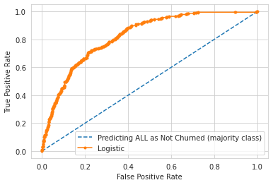

```python
######################################################
### fit w/ best parameters
best_model0 = LogisticRegression(**best_param_dict)
X_train, y_train = select_data(best_sampling_method)
best_model0.fit(X_train, y_train)
y_pred = best_model0.predict(X_test_onehot)
roc_auc_logistic = roc_auc_score(y_test_onehot, y_pred)

print('Test ROC_AUC of best Logistic Regression [Benchmark Model]: ' + str(round(roc_auc_logistic, 3)))


######################################################
# precision and recall
precision = precision_score(y_test_onehot, y_pred)
recall = recall_score(y_test_onehot, y_pred)
print('Precision: ' + str(round(precision, 3)))
print('Recall: ' + str(round(recall, 3)))

### Plot ROC-AUC and other metrics
ns_probs = [0 for _ in range(len(y_test_onehot))]

# predict probabilities
lr_probs = best_model0.predict_proba(X_test_onehot)

# keep probabilities for the positive outcome only
lr_probs = lr_probs[:, 1]

# calculate scores
ns_auc = roc_auc_score(y_test_onehot, ns_probs)
lr_auc = roc_auc_score(y_test_onehot, lr_probs)

# summarize scores
print('No Skill: ROC AUC=%.3f' % (ns_auc))
print('Logistic: ROC AUC=%.3f' % (lr_auc))

# calculate roc curves
ns_fpr, ns_tpr, _ = roc_curve(y_test_onehot, ns_probs)
lr_fpr, lr_tpr, _ = roc_curve(y_test_onehot, lr_probs)

# plot the roc curve for the model
plt.plot(ns_fpr, ns_tpr, linestyle='--', label='Predicting ALL as Not Churned (majority class)')
plt.plot(lr_fpr, lr_tpr, marker='.', label='Logistic')

# axis labels
plt.xlabel('False Positive Rate')
plt.ylabel('True Positive Rate')

# show the legend
plt.legend()

# show the plot
plt.show()
```

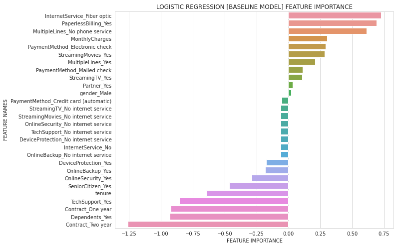

```python
plot_feature_importance(best_model0.coef_[0], X_test_onehot.columns,'LOGISTIC REGRESSION [BASELINE MODEL] ')
```

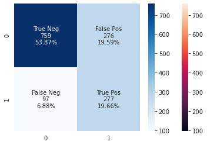

```python
from sklearn.metrics import confusion_matrix
y_pred = best_model0.predict(X_test_onehot)

cf_matrix = confusion_matrix(y_test_onehot, y_pred)
import seaborn as sns
sns.heatmap(cf_matrix, annot=True, fmt='g')


group_names = ['True Neg','False Pos','False Neg','True Pos']
group_counts = ["{0:0.0f}".format(value) for value in
                cf_matrix.flatten()]
group_percentages = ["{0:.2%}".format(value) for value in
                     cf_matrix.flatten()/np.sum(cf_matrix)]
labels = [f"{v1}\n{v2}\n{v3}" for v1, v2, v3 in
          zip(group_names,group_counts,group_percentages)]
labels = np.asarray(labels).reshape(2,2)
sns.heatmap(cf_matrix, annot=labels, fmt='', cmap='Blues')
```

```python
# print(best_model0.get_feature_names())
coef = best_model0.coef_[0]
print(X_train.columns)
print(coef)

result = pd.DataFrame({
    "col_names": X_train.columns,
    "weights": coef
})

result.sort_values('weights')
```

```
Index(['SeniorCitizen_Yes', 'TechSupport_No internet service',
       'TechSupport_Yes', 'Contract_One year', 'Contract_Two year',
       'PaperlessBilling_Yes', 'InternetService_Fiber optic',
       'InternetService_No', 'DeviceProtection_No internet service',
       'DeviceProtection_Yes', 'StreamingTV_No internet service',
       'StreamingTV_Yes', 'gender_Male', 'Dependents_Yes', 'Partner_Yes',
       'PaymentMethod_Credit card (automatic)',
       'PaymentMethod_Electronic check', 'PaymentMethod_Mailed check',
       'OnlineBackup_No internet service', 'OnlineBackup_Yes',
       'MultipleLines_No phone service', 'MultipleLines_Yes',
       'StreamingMovies_No internet service', 'StreamingMovies_Yes',
       'OnlineSecurity_No internet service', 'OnlineSecurity_Yes', 'tenure',
       'MonthlyCharges'],
      dtype='object')
[-0.46283129 -0.06243595 -0.85397958 -0.9203894  -1.25948354  0.69004272
  0.72679099 -0.06243595 -0.06243595 -0.17296809 -0.06243595  0.10913944
  0.02184399 -0.92885205  0.03490464 -0.05115679  0.29268319  0.11042355
 -0.06243595 -0.18003487  0.61167303  0.20804007 -0.06243595  0.28515561
 -0.06243595 -0.28832088 -0.64453707  0.30311006]
```

|  | col_names | weights |
| --- | --- | --- |
| 4 | Contract_Two year | -1.259484 |
| 13 | Dependents_Yes | -0.928852 |
| 3 | Contract_One year | -0.920389 |
| 2 | TechSupport_Yes | -0.853980 |
| 26 | tenure | -0.644537 |
| 0 | SeniorCitizen_Yes | -0.462831 |
| 25 | OnlineSecurity_Yes | -0.288321 |
| 19 | OnlineBackup_Yes | -0.180035 |
| 9 | DeviceProtection_Yes | -0.172968 |
| 7 | InternetService_No | -0.062436 |
| 8 | DeviceProtection_No internet service | -0.062436 |
| 10 | StreamingTV_No internet service | -0.062436 |
| 1 | TechSupport_No internet service | -0.062436 |
| 22 | StreamingMovies_No internet service | -0.062436 |
| 18 | OnlineBackup_No internet service | -0.062436 |
| 24 | OnlineSecurity_No internet service | -0.062436 |
| 15 | PaymentMethod_Credit card (automatic) | -0.051157 |
| 12 | gender_Male | 0.021844 |
| 14 | Partner_Yes | 0.034905 |
| 11 | StreamingTV_Yes | 0.109139 |
| 17 | PaymentMethod_Mailed check | 0.110424 |
| 21 | MultipleLines_Yes | 0.208040 |
| 23 | StreamingMovies_Yes | 0.285156 |
| 16 | PaymentMethod_Electronic check | 0.292683 |
| 27 | MonthlyCharges | 0.303110 |
| 20 | MultipleLines_No phone service | 0.611673 |
| 5 | PaperlessBilling_Yes | 0.690043 |
| 6 | InternetService_Fiber optic | 0.726791 |